# YouTube Project

### Question 12 Find the title of the video which has the maximum number of dislikes and the title of the video having minimum dislikes and write your inferences.

```python
max_dlike=data_dummy.groupby('title')['dislikes'].max().sort_values(ascending=False).head(1)
print(max_dlike)
```

```
title
Cuties | Official Trailer | Netflix    2397733
Name: dislikes, dtype: int64
```

```python
min_dlike=data_dummy.groupby('title')['dislikes'].max().sort_values(ascending=True).head(1)
print(min_dlike)
```

[output not shown]

```python
"""The least dislikes video is: 'Kim Kardashian\'s Must-See Moments on "Saturday Night Live" | E! News and the most disliked video is 'Cuties | Official Trailer | Netflix'.  """
```

### 13 Does the number of views have any effect on how many people disliked the video? Support your answer with a metric and a plot.

```python
data_dummy.loc[:,['likes','dislikes','view_count']]
```

|  | likes | dislikes | view_count |
| --- | --- | --- | --- |
| 0 | 19515 | 226 | 1048888 |
| 1 | 359277 | 7479 | 15352638 |
| 2 | 11212 | 401 | 925281 |
| 3 | 39131 | 441 | 2641597 |
| 4 | 32887 | 367 | 715724 |
| ... | ... | ... | ... |
| 37417 | 2180780 | 35871 | 120408275 |
| 37418 | 20759 | 1049 | 2841917 |
| 37419 | 720854 | 4426 | 13346678 |
| 37420 | 19198 | 1234 | 252057 |
| 37421 | 34063 | 868 | 2252090 |

```python
data_dummy.corr()
```

|  | view_count | likes | dislikes | comment_count |
| --- | --- | --- | --- | --- |
| view_count | 1.000000 | 0.784229 | 0.684469 | 0.464392 |
| likes | 0.784229 | 1.000000 | 0.679817 | 0.580953 |
| dislikes | 0.684469 | 0.679817 | 1.000000 | 0.391739 |
| comment_count | 0.464392 | 0.580953 | 0.391739 | 1.000000 |

```python
correlation=data_dummy.dislikes.corr(data_dummy.view_count)
print(correlation)
```

```
0.6844687753905543
```

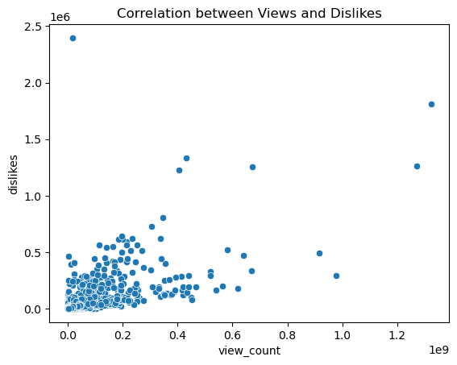

```python
sns.scatterplot(data_dummy,y='dislikes',x='view_count')
plt.title("Correlation between Views and Dislikes")
plt.show()
```

```python
'The correlation between the view & dislike is 0.68.it means both are positvely co-related to each other and strength of this relationship is 68%'
```

```
'The correlation between the view & dislike is 0.68.it means both are positvely co-related to each other and strength of this relationship is 68%'
```

### 14 Display all the information about the videos that were published in January, and mention the count of videos that were published in January

```python
jan_video=data_dummy[data_dummy.published_month.isin(["Jan"])]
jan_video
```

|  | video_id | title | channel_id | channel_title | published_at | view_count | likes | dislikes | comment_count | tags | description | comments | published_month |
| --- | --- | --- | --- | --- | --- | --- | --- | --- | --- | --- | --- | --- | --- |
| 27 | -2Gwm7QfBnE | Q&A With Naisha | UCYwNMbogQFzMccPSuy-pPWg | MianTwins | 2021-01-21 00:05:47 | 872372 | 38626 | 239 | 621 |  | Hey Guys!!! this has been the most requested v... | I feel like Nate and Aishas personality match ... | Jan |
| 48 | -4sfXSHSxzA | SURPRISING BRENT WITH HIS TIKTOK CRUSH!! | UCPpATKqmMV-CNRNWYaDUwiA | Alexa Rivera | 2021-01-16 21:40:04 | 6504784 | 262477 | 5779 | 7907 |  | He had no idea! Thank you guys so much for wat... | Thank you guys for watching and don't forget t... | Jan |
| 95 | -AJD1Fc5rpQ | WE ARE HAVING A BABY! \| finding out i'm pregna... | UCVsTboAhpnuL6j-tDePvNwQ | Tess Christine | 2021-01-03 21:53:48 | 533084 | 38965 | 119 | 1650 |  | I am so happy to tell you that I am pregnant!!... | Okay I needed a moment to collect my thoughts ... | Jan |
| 103 | -AuJiwjsmWk | Do Ugly Foods Taste Worse? Taste Test | UCzpCc5n9hqiVC7HhPwcIKEg | Good Mythical MORE | 2021-01-19 11:00:01 | 1057077 | 22526 | 531 | 773 | gmm good mythical morning rhettandlink rhett a... | Today, we're doing a blind taste test to deter... | "there's nothing wrong with it being bent"\nI ... | Jan |
| 182 | -JhqO2KWr5U | Schlatt gets fit | UCWZp4y1jqBuvLtiyxSs_ZBw | Big guy | 2021-01-24 22:50:57 | 1724965 | 119431 | 325 | 1578 | jschlatt big guy jschlatt highlights schlatt j... | #jschlatt #schlatt #bigguy #short | Schlatt is single handedly wiping out all the ... | Jan |
| ... | ... | ... | ... | ... | ... | ... | ... | ... | ... | ... | ... | ... | ... |
| 37300 | zmzFL5bG-jc | DEVINE MON PERSONNAGE AVANT AKINATOR ! (c'est ... | UCIlr3byh6wmXgcPx_Tm9Ocw | Piwerre | 2021-01-16 16:12:19 | 670357 | 54462 | 832 | 1249 | Piwerre frere de michou crouton among us devin... | Discord Piwerre : https://discord.gg/QBduPgAA... | Mdr michou quand c'est pas ses tournage il fou... | Jan |
| 37329 | zpzjex7qwrA | Lampard Sacked Within Days Rorys Misery \| Chel... | UCkD-ZOixI0a9FjIExDsHsbg | The Kick Off | 2021-01-03 20:13:49 | 428646 | 12060 | 296 | 1505 | Premier league Chelsea chelsea 1-3 Man City Ch... | The Kick Off watched Manchester City destroy C... | True Its like a fighter who Geordie But I thou... | Jan |
| 37345 | zqyv-B6mnBM | Lil Wayne - Ain't Got Time (Audio) | UCO9zJy7HWrIS3ojB4Lr7Yqw | Lil Wayne | 2021-01-21 05:00:10 | 2238244 | 58925 | 2365 | 5539 | lil wayne weezy weezy wednesday wayne carter y... | Official audio for Lil Wayne "Ain't Got Time",... | RIP Juice Wrld, wrote that on two cups, pour o... | Jan |
| 37383 | zwfu1-24T7Q | PRADA Cup Day 1 \| Full Race Replay \| PRADA Cup... | UCo15ZYO_XDRU9LI30OPtxAg | America's Cup | 2021-01-15 04:07:55 | 317382 | 2008 | 83 | 192 | America's Cup Americas Cup AC36 AC75 Presented... | The opening day of the PRADA Cup in Auckland, ... | Incredible how these boats evolve in a short t... | Jan |
| 37418 | zziBybeSAtw | PELICANS at LAKERS \| FULL GAME HIGHLIGHTS \| Ja... | UCWJ2lWNubArHWmf3FIHbfcQ | NBA | 2021-01-16 05:39:05 | 2841917 | 20759 | 1049 | 2624 | NBA G League Basketball game-0022000187 Lakers... | PELICANS at LAKERS \| FULL GAME HIGHLIGHTS \| Ja... | Montrezl Harrell is going crazy with the rebou... | Jan |

2108 rows × 13 columns

```python
z=jan_video.shape[0]
print(f'Videos that were published in January: {z}')
```

```
Videos that were published in January: 2108
```